# Projekt 3.0

Bartłomiej Fatyga

25 maja 2018

# Budowa modelu liniowego za pomocą klasycznych metod ekonometrycznych oraz metod boostrapowaych.

## Opis problemu

Celem projektu jest budowa liniowego modelu dla spalania w danych dotyczących samochodów osobowych z pliku cars.csv. Kolejnym etapem jest porówananie modelu zbudowanego za pomocą klasycznych metod ekonometrycznych z modelem zbudowanym za pomocą metod boostrapowych.

## Przedstawienie hipotez

Hipoteza 1: Zmienne dobrane za pomocą metod boostrapowych charakteryzują się “lepszymi” przedziałami ufności tj. większość wyników będzie skupiona bliżej średniej.

## Opis danych

Naszą próbkę stanowić będą dane z pliku cars.csv. Opisują one wiele samochodów dostępnych na rynku w latach 1970 - 1982. Opisywane parametry:

- mpg - spalanie w galonach na milę
- cylinders - liczba cylindrów
- displacement - objętość silnika w calach sześciennych
- horsepower - moc w koniach mechanicznych
- weight - waga w funtach
- acceleration - czas przyspieszenia do 0 do 60 mil na godzinę, podany w sekundach
- year - rok produkcji
- origin - miejsce produkcji
- name - nazwa samochodu

Pierwszą część analizy zacząłem od przekształcenia jednostek na system europejski, z wyłączeniem *acceleration*, gdyż taka zamiana nie byłaby możliwa. W takim wypadku zmienna *mpg* zmienia nazwę na *lp100k*. Po wszystkich przekształceniach dane przyjmują postać:

```r
head(samochodziki, 10)
```

```
## # A tibble: 10 x 9
##    lp100k cylinders displacement horsepower weight acceleration  year
##     <dbl>     <int>        <dbl>      <int>  <dbl>        <dbl> <int>
##  1   9.80         4        1475.         75   956.         15.5    74
##  2  11.2          6        3277.         85  1173.         16.0    70
##  3   7.47         4        1458.         71   903.         14.9    78
##  4  12.1          6        3802.         90  1456.         17.2    78
##  5  13.1          6        3687.        105  1416.         16.5    73
##  6   8.11         4        1114.         49   847.         19.5    73
##  7  12.4          6        3687.        100  1647.         17.7    77
##  8   9.05         4        1999.         80  1112.         16.5    74
##  9   7.71         4        1590.         78   993.         14.1    77
## 10  14.3          6        2753.        120  1733.         16.7    76
## # ... with 2 more variables: origin <int>, name <chr>
```

# Analiza wizualna oraz opisowa

## Podstawowe statystki opisowe

```r
summary(samochodziki[1:7])
```

```
##      lp100k         cylinders     displacement    horsepower
##  Min.   : 5.048   Min.   :3.00   Min.   :1114   Min.   : 46.0
##  1st Qu.: 8.111   1st Qu.:4.00   1st Qu.:1606   1st Qu.: 75.0
##  Median :10.227   Median :4.00   Median :2474   Median : 95.0
##  Mean   :11.219   Mean   :5.49   Mean   :3183   Mean   :104.6
##  3rd Qu.:13.441   3rd Qu.:8.00   3rd Qu.:4806   3rd Qu.:128.0
##  Max.   :26.135   Max.   :8.00   Max.   :7456   Max.   :230.0
##      weight        acceleration        year
##  Min.   : 731.6   Min.   : 8.00   Min.   :70.00
##  1st Qu.:1003.5   1st Qu.:13.70   1st Qu.:73.00
##  Median :1270.5   Median :15.50   Median :76.00
##  Mean   :1349.1   Mean   :15.49   Mean   :75.98
##  3rd Qu.:1651.9   3rd Qu.:17.00   3rd Qu.:79.00
##  Max.   :2331.5   Max.   :23.70   Max.   :82.00
```

Podstawowe statystyki opisowe sugerują nam, że mamy do czynienia z bardzo zróżnicowanymi danymi.

## Wizualizacja danych

### Wykres spalania od pojemności z uwzględnieniem liczby koni mechanicznych

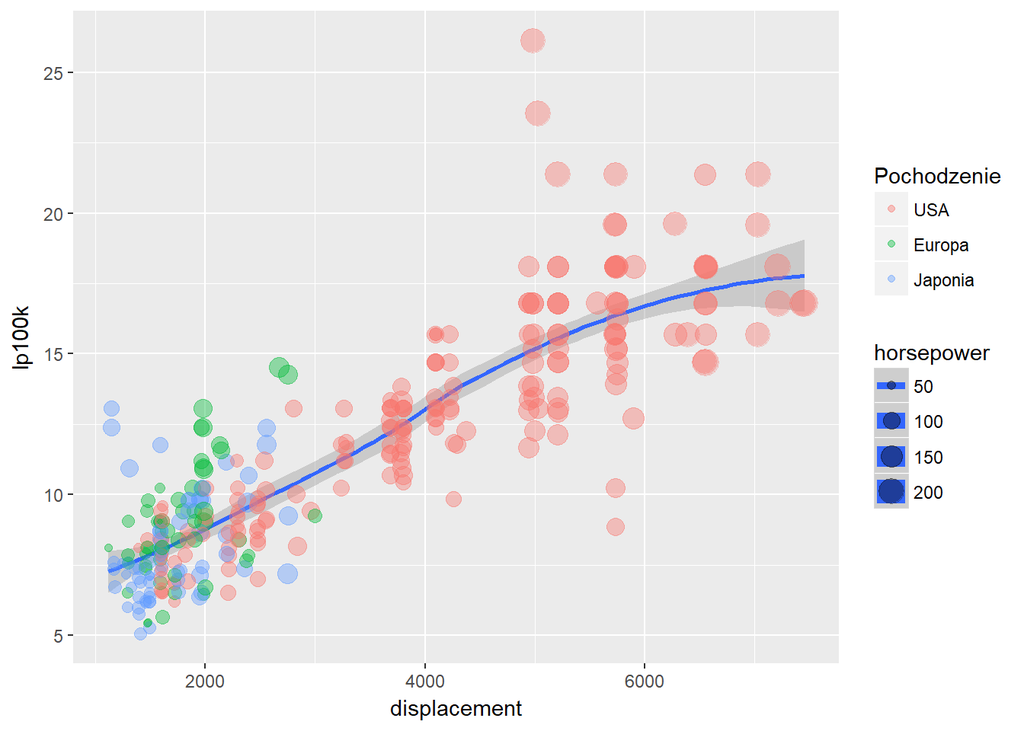

Pierwszy wykres dostarcza nam bardzo wielu informacji:

- Wyraźnie widać, że USA produkuje samochody o największej pojemności silnika.
- Widać trend rosnący -> wraz ze wzrostem pojemności silnika powinniśmy się spodziewać wzrostu średniego spalania.
- Dane sugerują nam również korelację między pojemnością silnika, a liczbą koni mechanicznych, co może nam utrudnić analizę.

### Wykres spalania od cylindrów

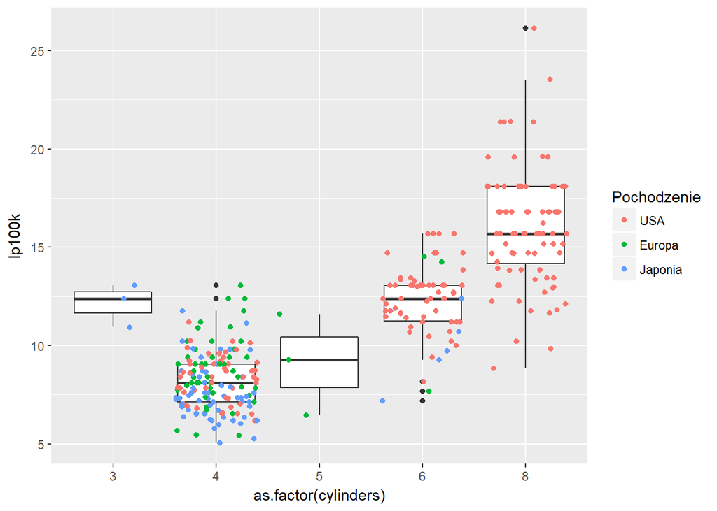

- Jak w poprzednim wykresie samochody o największej ilości cylindrów produkowane są w USA.
- Widoczny jest wzrost spalania wraz ze wzrostem liczby cylindrów. Może to nam sugerować kolejną korelację liczby cylindrów, z pojemnością silnika lub/oraz z liczbą koni mechanicznych.

### Wykres spalania od koni mechanicznych

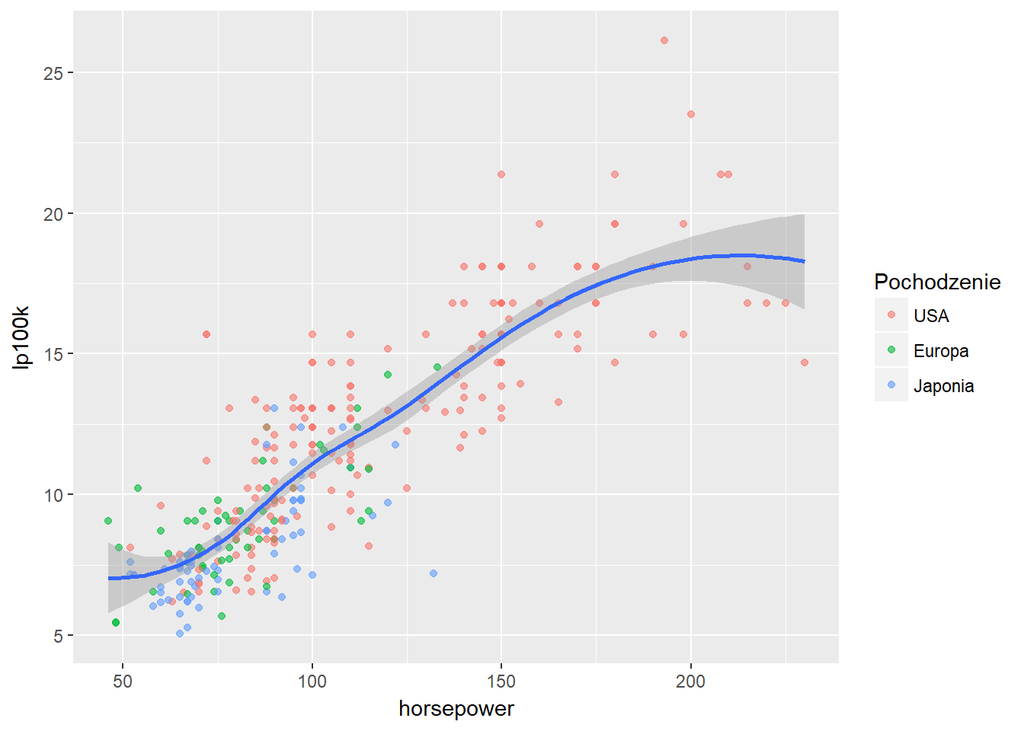

Biorąc pod uwagę poprzednie wykresy możemy stwierdzić, iż ten wykres nie dostarcza nam wielu istotnych informacji, oprócz potwierdzenia, że liczba koni mechanicznych jest związana ze spalaniem.

### Wykres spalania od wagi

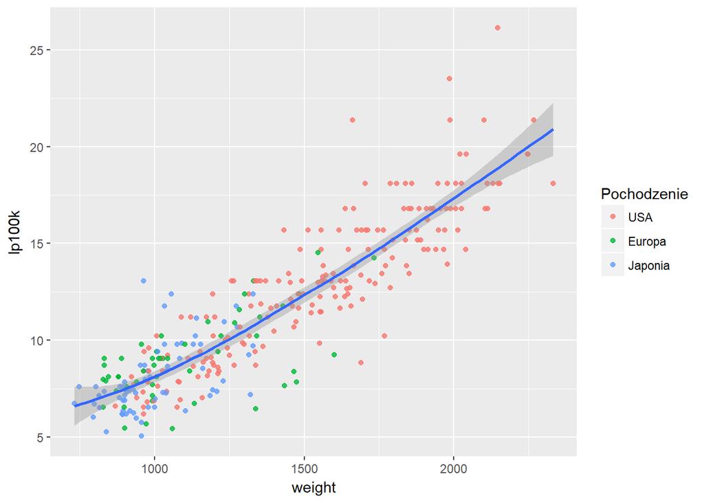

- Waga ma dodatni wpływ na spalanie.
- Waga samochodu może być skorelowana z liczbą koni mechanicznych.

### Wykres spalania od przyspieszenia

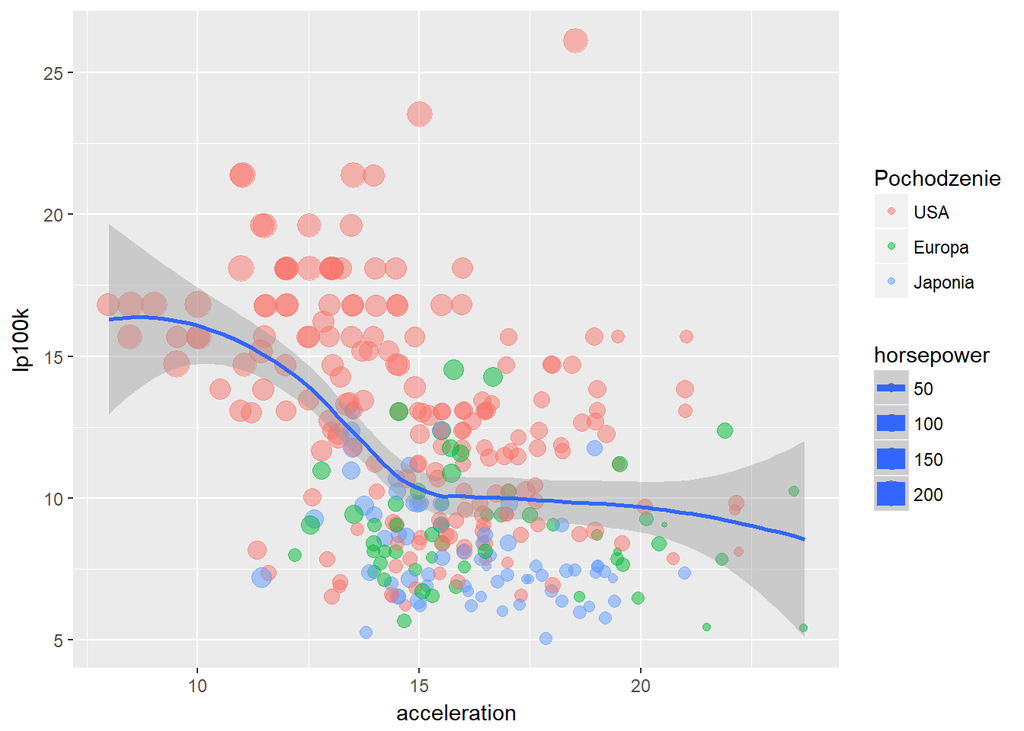

Ten wykres prowadzi do wniosków:

- Liczba koni mechanicznych jest skorelowana z przyspieszeniem (co po raz kolejny nie jest sporym zaskoczeniem).
- Najszybsze samochody są produkowane w USA.
- Można również pokusić się o stwierdzenie, że samochody produkowane w Europie i Japoni charakteryzują się mnieszym spalaniem, przy porównywalnym przyspieszenie niż samochody produkowane w USA.
- Nie widać gładkiej liniwej zależności między spalaniem, a przyspieszniem. Jednak istnieje ujemna zależność między spalanie, a przyspieszeniem.

### Wykres spalania od roku produkcji

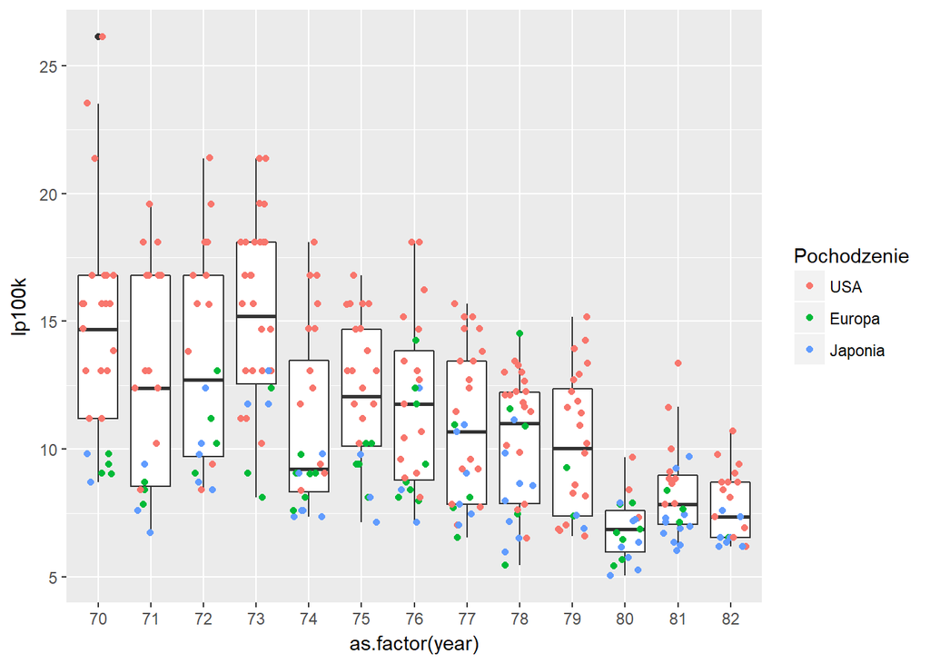

Wykres ten obrazuje nam dwie ważne zależności:

- Samochody produkowane w Europie i Japoni charakteryzują się mnieszym spalanie, niż te produkowane w USA.
- Wyraźnie jest widoczny malejący trend. Z kolejnumi latami średnie spalanie spadało. Dodatkowo można dodać, że najwięcej spadało wśród samochodów produkwanych w USA.

Dostrzegając spore zagrożenie korelacji zdecydowałem się stworzyć macierz korealcji, by sprawdzić swoje przypuszczenia.

### Macierz korelacji

```r
cor(samochodziki[1:7])
```

```
##                  lp100k  cylinders displacement horsepower     weight
## lp100k        1.0000000  0.8391160    0.8684797  0.8541834  0.8947414
## cylinders     0.8391160  1.0000000    0.9507553  0.8454506  0.8991250
## displacement  0.8684797  0.9507553    1.0000000  0.8959796  0.9366893
## horsepower    0.8541834  0.8454506    0.8959796  1.0000000  0.8697402
## weight        0.8947414  0.8991250    0.9366893  0.8697402  1.0000000
## acceleration -0.4201332 -0.4776420   -0.5242503 -0.6761240 -0.3867368
## year         -0.5526546 -0.3518177   -0.3747302 -0.4232779 -0.3186360
##              acceleration       year
## lp100k         -0.4201332 -0.5526546
## cylinders      -0.4776420 -0.3518177
## displacement   -0.5242503 -0.3747302
## horsepower     -0.6761240 -0.4232779
## weight         -0.3867368 -0.3186360
## acceleration    1.0000000  0.2815230
## year            0.2815230  1.0000000
```

Z powodu sposobu wyświetlania danych lepiej w tym przypadku posłużyć się wykresem, który zobrazuje nam te korelacje.

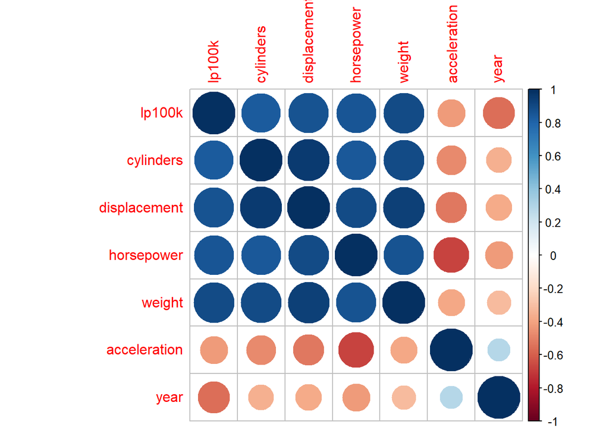

Wykres ten w dobitny sposób wskazuję nam, że zmienne *cylinders, displacement, horsepower, weight* są ze sobą silnie skorelowane. Resztę zależności udało nam się wykryć w poprzedniach wykresach.

## Podsumowanie analizy wizualnej oraz opisowej

Po pierwsze ze względu na korelację między zmiennymi *cylinders, displacement, horsepower, weight* możemy spodziewać się, że część z nich nie znajdzie się w naszym modelu. Korelacja między *acceleration*, a *horsepower* sugeruję, że w naszym modelu możemy spodziewać się jednej z tych dwóch zmiennych. Dodatkowo w naszym modelu powinna znaleźć się zmienna *year*, gdyż charakteryzuje się korelacją ze spalanie, a korelacje między resztą zmiennych nie są znaczące.

# Budowa modelu liniowego

## Metoda backward selection

### Pierwszy model

```
##
## Call:
## lm(formula = lp100k ~ cylinders + displacement + horsepower +
##     weight + acceleration + year + as.factor(origin), data = samochodziki)
##
## Residuals:
##     Min      1Q  Median      3Q     Max
## -3.4462 -0.7744 -0.0793  0.7157  5.8621
##
## Coefficients:
##                      Estimate Std. Error t value Pr(>|t|)
## (Intercept)        21.8453936  2.1401645  10.207  < 2e-16 ***
## cylinders           0.2501058  0.1414740   1.768  0.07808 .
## displacement       -0.0004275  0.0002104  -2.031  0.04310 *
## horsepower          0.0260460  0.0064097   4.064 6.15e-05 ***
## weight              0.0064026  0.0006968   9.188  < 2e-16 ***
## acceleration        0.0727435  0.0462243   1.574  0.11659
## year               -0.3014097  0.0235157 -12.817  < 2e-16 ***
## as.factor(origin)2 -0.6889822  0.2563482  -2.688  0.00759 **
## as.factor(origin)3 -0.4835312  0.2458508  -1.967  0.05012 .
## ---
## Signif. codes:  0 '***' 0.001 '**' 0.01 '*' 0.05 '.' 0.1 ' ' 1
##
## Residual standard error: 1.315 on 305 degrees of freedom
## Multiple R-squared:  0.8898, Adjusted R-squared:  0.8869
## F-statistic: 307.8 on 8 and 305 DF,  p-value: < 2.2e-16
```

W tym modelu zmienną o największym p-value jest *acceleration* więc to ją zdecydowałem się odrzucić.

### Drugi model

```
##
## Call:
## lm(formula = lp100k ~ cylinders + displacement + horsepower +
##     weight + year + as.factor(origin), data = samochodziki)
##
## Residuals:
##     Min      1Q  Median      3Q     Max
## -3.2212 -0.8139 -0.0688  0.6561  5.9905
##
## Coefficients:
##                      Estimate Std. Error t value Pr(>|t|)
## (Intercept)        23.3610989  1.9157993  12.194  < 2e-16 ***
## cylinders           0.2525418  0.1418065   1.781  0.07592 .
## displacement       -0.0004911  0.0002070  -2.372  0.01831 *
## horsepower          0.0193863  0.0048257   4.017 7.41e-05 ***
## weight              0.0070183  0.0005780  12.142  < 2e-16 ***
## year               -0.3058356  0.0234032 -13.068  < 2e-16 ***
## as.factor(origin)2 -0.6973874  0.2569102  -2.715  0.00701 **
## as.factor(origin)3 -0.4661482  0.2461943  -1.893  0.05925 .
## ---
## Signif. codes:  0 '***' 0.001 '**' 0.01 '*' 0.05 '.' 0.1 ' ' 1
##
## Residual standard error: 1.318 on 306 degrees of freedom
## Multiple R-squared:  0.8889, Adjusted R-squared:  0.8863
## F-statistic: 349.7 on 7 and 306 DF,  p-value: < 2.2e-16
```

Największe p-value -> zmienna *cylinders* -> odrzucamy.

### Trzeci model

```
##
## Call:
## lm(formula = lp100k ~ displacement + horsepower + weight + year +
##     as.factor(origin), data = samochodziki)
##
## Residuals:
##     Min      1Q  Median      3Q     Max
## -3.3369 -0.8438 -0.0680  0.6726  6.0528
##
## Coefficients:
##                      Estimate Std. Error t value Pr(>|t|)
## (Intercept)        23.9504082  1.8936670  12.648  < 2e-16 ***
## displacement       -0.0002538  0.0001590  -1.596 0.111517
## horsepower          0.0186467  0.0048247   3.865 0.000136 ***
## weight              0.0071204  0.0005772  12.336  < 2e-16 ***
## year               -0.3062271  0.0234848 -13.039  < 2e-16 ***
## as.factor(origin)2 -0.6816612  0.2576648  -2.646 0.008576 **
## as.factor(origin)3 -0.4257419  0.2460121  -1.731 0.084533 .
## ---
## Signif. codes:  0 '***' 0.001 '**' 0.01 '*' 0.05 '.' 0.1 ' ' 1
##
## Residual standard error: 1.323 on 307 degrees of freedom
## Multiple R-squared:  0.8877, Adjusted R-squared:  0.8855
## F-statistic: 404.6 on 6 and 307 DF,  p-value: < 2.2e-16
```

Odrzucamy zmienną *displacement*.

### Czwarty model

```
##
## Call:
## lm(formula = lp100k ~ horsepower + weight + year + as.factor(origin),
##     data = samochodziki)
##
## Residuals:
##     Min      1Q  Median      3Q     Max
## -3.3006 -0.7922 -0.0459  0.6358  6.4451
##
## Coefficients:
##                      Estimate Std. Error t value Pr(>|t|)
## (Intercept)        23.8444390  1.8972501  12.568  < 2e-16 ***
## horsepower          0.0150023  0.0042608   3.521 0.000495 ***
## weight              0.0065161  0.0004367  14.920  < 2e-16 ***
## year               -0.3005158  0.0232688 -12.915  < 2e-16 ***
## as.factor(origin)2 -0.5013239  0.2321489  -2.159 0.031584 *
## as.factor(origin)3 -0.2915555  0.2317792  -1.258 0.209380
## ---
## Signif. codes:  0 '***' 0.001 '**' 0.01 '*' 0.05 '.' 0.1 ' ' 1
##
## Residual standard error: 1.326 on 308 degrees of freedom
## Multiple R-squared:  0.8868, Adjusted R-squared:  0.885
## F-statistic: 482.6 on 5 and 308 DF,  p-value: < 2.2e-16
```

Na tym etapie decydujemy się odrzucić zmienną *origin*.

### Piąty model

```
##
## Call:
## lm(formula = lp100k ~ horsepower + weight + year, data = samochodziki)
##
## Residuals:
##     Min      1Q  Median      3Q     Max
## -3.3229 -0.7818 -0.0626  0.6344  6.3843
##
## Coefficients:
##               Estimate Std. Error t value Pr(>|t|)
## (Intercept) 22.8668314  1.8503686  12.358  < 2e-16 ***
## horsepower   0.0151390  0.0042094   3.596 0.000375 ***
## weight       0.0068079  0.0003937  17.294  < 2e-16 ***
## year        -0.2950063  0.0230468 -12.800  < 2e-16 ***
## ---
## Signif. codes:  0 '***' 0.001 '**' 0.01 '*' 0.05 '.' 0.1 ' ' 1
##
## Residual standard error: 1.332 on 310 degrees of freedom
## Multiple R-squared:  0.885,  Adjusted R-squared:  0.8839
## F-statistic: 795.5 on 3 and 310 DF,  p-value: < 2.2e-16
```

Możemy zakwalifkiować ten model jako najlepszy i użyjemy go do reszty naszych analiz.

## Wykres wartości rzeczywistych i dopasowanych

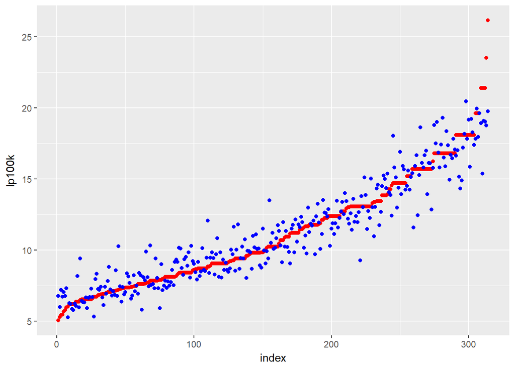

## Test Jarque-Bera dla normalności

```
##
##  Jarque Bera Test
##
## data:  model_classic$residuals
## X-squared = 179.32, df = 2, p-value < 2.2e-16
```

## Próba bootstrap na podstawie obserwacji

```
## Classes 'tbl_df', 'tbl' and 'data.frame':    314 obs. of  9 variables:
##  $ lp100k      : num  9.8 11.2 7.47 12.12 13.07 ...
##  $ cylinders   : int  4 6 4 6 6 4 6 4 4 6 ...
##  $ displacement: num  1475 3277 1458 3802 3687 ...
##  $ horsepower  : int  75 85 71 90 105 49 100 80 78 120 ...
##  $ weight      : num  956 1173 903 1456 1416 ...
##  $ acceleration: num  15.5 16 14.9 17.2 16.5 19.5 17.7 16.5 14.1 16.7 ...
##  $ year        : int  74 70 78 78 73 73 77 74 77 76 ...
##  $ origin      : int  2 1 2 1 1 2 1 1 2 2 ...
##  $ name        : chr  "fiat 128" "ford maverick" "volkswagen scirocco" "amc concord" ...
```

Kolejno dla *horsepower, weight, year*:

```
##     Min.  1st Qu.   Median     Mean  3rd Qu.     Max.
## -0.01459  0.01077  0.01511  0.01531  0.01962  0.04894
```

```
##     Min.  1st Qu.   Median     Mean  3rd Qu.     Max.
## 0.004184 0.006449 0.006803 0.006796 0.007153 0.009352
```

```
##    Min. 1st Qu.  Median    Mean 3rd Qu.    Max.
## -0.3983 -0.3091 -0.2946 -0.2949 -0.2805 -0.2113
```

## Przedziały ufności dla modelu klasycznego

### Przedziały ufności dla zmiennej *horsepower*:

| Poziom istotności | Lewy przedział | Prawy przedział |
| --- | --- | --- |
| 90% | 0.0082152 | 0.0220628 |
| 95% | 0.0068888 | 0.0233892 |
| 99% | 0.0042964 | 0.0259816 |

### Przedziały ufności dla zmiennej *weight*:

| Poziom istotności | Lewy przedział | Prawy przedział |
| --- | --- | --- |
| 90% | 0.0061604 | 0.0074554 |
| 95% | 0.0060363 | 0.0075794 |
| 99% | 0.0057939 | 0.0078219 |

### Przedziały ufności dla zmiennej *year*:

| Poziom istotności | Lewy przedział | Prawy przedział |
| --- | --- | --- |
| 90% | -0.3329149 | -0.2570977 |
| 95% | -0.3401771 | -0.2498354 |
| 99% | -0.3543709 | -0.2356417 |

## Przedziały ufności dla modelu bootstrap

### Przedziały ufności dla zmiennej *horsepower*:

[output not shown]

### Przedziały ufności dla zmiennej *weight*:

| Poziom istotności | Lewy przedział | Prawy przedział |
| --- | --- | --- |
| 90% | 0.0059208 | 0.0076423 |
| 95% | 0.0057497 | 0.0077929 |
| 99% | 0.0054149 | 0.0080901 |

### Przedziały ufności dla zmiennej *year*:

| Poziom istotności | Lewy przedział | Prawy przedział |
| --- | --- | --- |
| 90% | -0.3302265 | -0.2607749 |
| 95% | -0.3373669 | -0.2544503 |
| 99% | -0.3520068 | -0.2419897 |

## Porównanie przedziałów

### Dla zmiennej *horsepower*

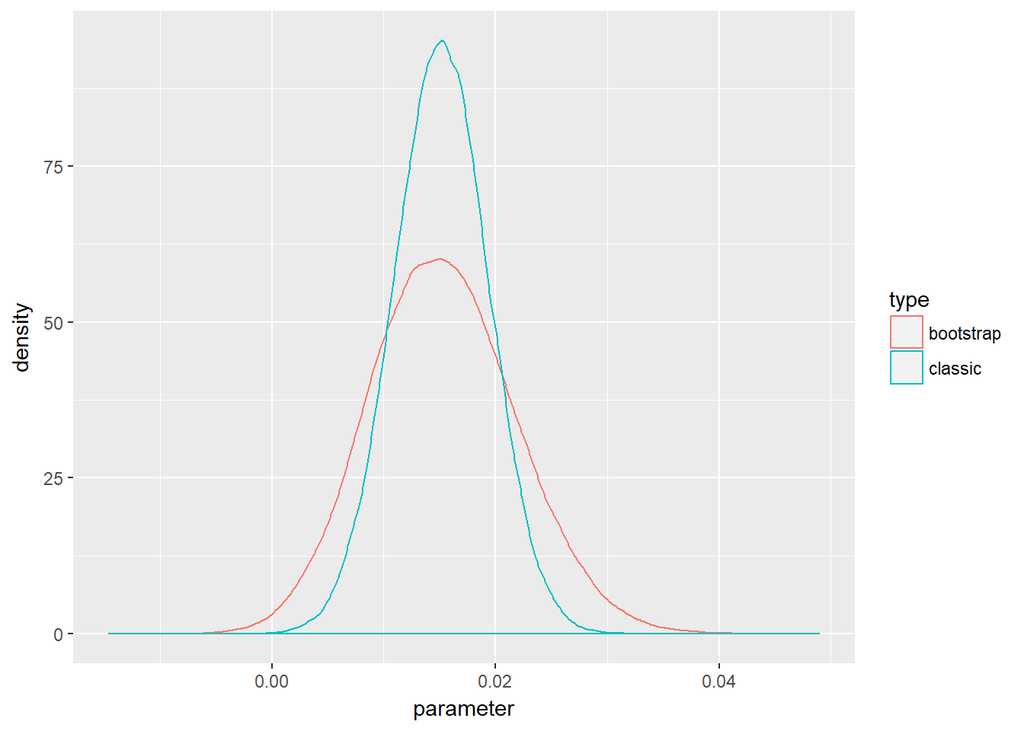

### Dla zmiennej *weight*

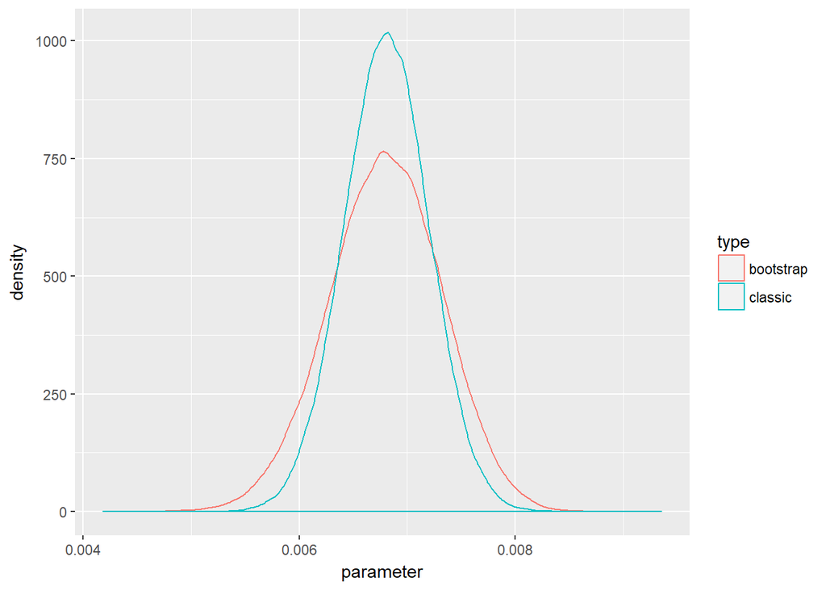

### Dla zmiennej *year*

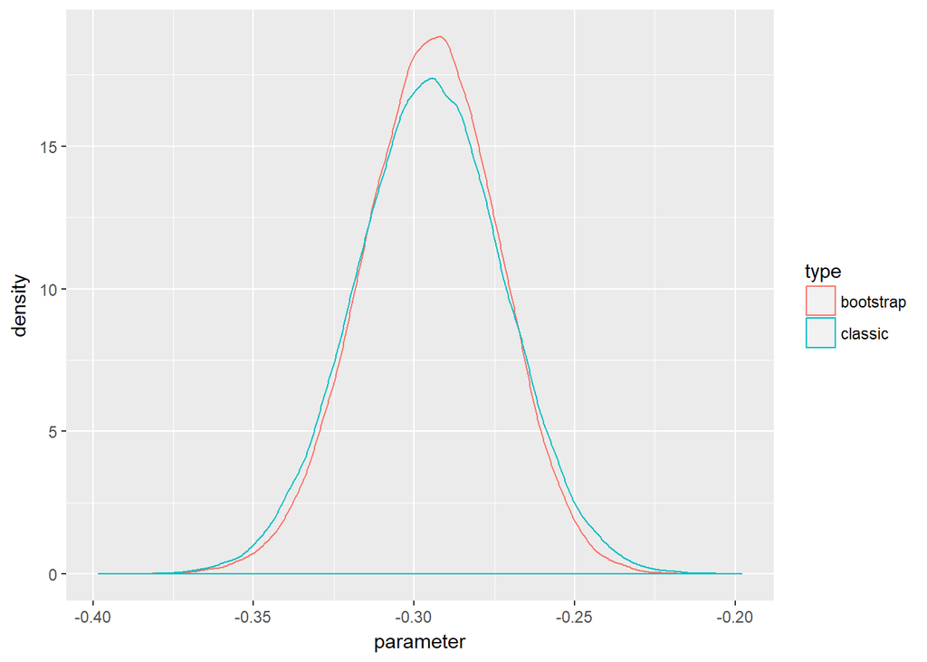

# Podsumowanie. Interpretacja i wnioski z analizy

Zacznę od krótkiego przypomnienia na czym polegały dwa sposoby liczenia przedziałów ufności, jakich wyników się spodziewam w kontrze do tego jakie otrzymałem.

Przede wszystkim musimy pamiętać, że **test-t** w **Metodzie najmniejszych kwadratów** jest uzależniony od założenia normalności reszt modelu. Jeśli jesteśmy pewni, że tak jest to **statystyka t** bardzo dokładnie określa nam “przydatność” parametrów. Dodatkowo dla duży prób (im większe tym lepiej) **rozkład t** zbliża się do rozkładu normalnego, pod warunkiem, że reszty są niezależna i mają taki sam rozkład.

Metody **boostrap** używamy, gdy nie jesteśmy pewnie co założenia normalności reszt, lub próbka jest zbyt mała. Więc przewagą metod **bootstrap** jest ich uniwersalność.